# BMI 714 Project

Harry Li, Stephanie Chen

2024-12-14

## EDA

This includes NA handling and correlation check between selected lab variables.

```r
var_lib <- read.csv('BMI714_NHANES_VariableDictionary.csv')
nhanes_2020 <- as.data.frame(fread("BMI714_NHANES2020_Data.csv", header = T, sep = ","))
# nhanes_2020 <- read.csv("BMI714_NHANES2020_Data.csv")

# the meta groups that exist within variables, I'm interested in laboratory
table(var_lib$Component)
```

```
##
##  Demographics       Dietary   Examination    Laboratory      multiple
##            28            96           255           438             1
## Questionnaire
##           777
```

### Dealing with NAs

```r
## first subset main dataframe to just lab variables
lab_var <- var_lib%>%
  filter(Component == "Laboratory")%>%
  pull(BMI_714_Variable_Name)

nhanes_lab <- nhanes_2020%>%
  select(all_of(lab_var))
#head(nhanes_lab)
```

Seems like there’s a lot of NAs, let’s see how bad it is

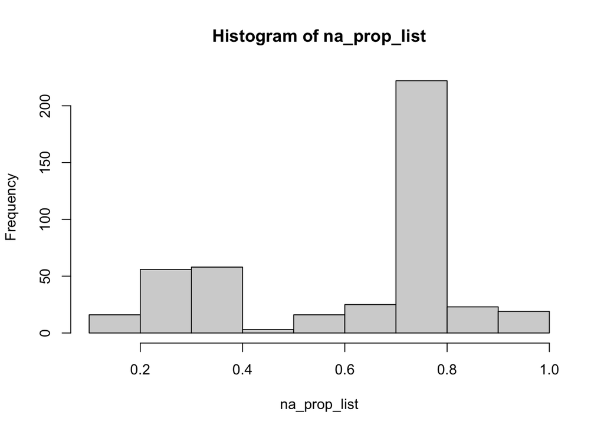

```r
# there exists no patient that did all 438 lab tests, so let's find a subset of lab vars for which we have a good size of patients
# drop_na(nhanes_lab)

# first let's see how many NA's each variable has
n_patients <- nrow(nhanes_lab)


# I changed from using read.csv to fread for importing nhanes and the code below is not working can you help?
na_prop_list <- c()
for (i in 1:ncol(nhanes_lab)) {
  na_prop_list[i] <- sum(is.na(nhanes_lab[,i]))/n_patients
}
names(na_prop_list) <- colnames(nhanes_lab)

hist(na_prop_list)
```

```r
# so a majority of the lab vars contain ~0.8 NA's

# let's set 0.5 as an NA threshold for subsetting lab variables,
# with the hope that the leftover lab vars will yield a non-zero patient cohort
low_na_vars <- names(na_prop_list[na_prop_list<0.5])
length(low_na_vars)
```

```
## [1] 133
```

```r
nrow(nhanes_lab%>%select(all_of(low_na_vars))%>%drop_na())
```

```
## [1] 4843
```

We saw that each of the lab variables have differing rate of NAs.

*sanity check*: if a variable A has 0.5 NA rate, then that means half of the total 15560 patients will have an NA for that variable. Our goal is to find a subset of patients and a set of variables for which there exists no NAs. If we introduce some variable B also with 0.5 NA rate and we find the patients that have no NA for either variable, we should expect a result size of less than half of 15560 because it’s not necessarily true that everyone who tested for var A also tested for var B (we can sure hope).

Thus, we have that 1) the lower the NA rate threshold, the less resulting variable subset, 2) the less resuling variable subset, the more patients will be leftover at the end. (consider the base case where only the lab var with NA rate of 0.00001 is left, which means almost all 15560 patients will be selected)

If we look at only the variables with at most 0.5 NA rate, we end up with ~5000 patients. Let’s see if we can do better, our goal is to maximize the size of subsetted variables while having the most patients we can work with.

```r
# set threshold value from 0.01 to 0.50, expect more consensus patient as threshold decrease
consensus_patient_n <- c()
filtered_var_n <- c()
i <- 1
for (t in seq(0.01, 0.5, by = 0.01)) {
  low_na_vars <- names(na_prop_list[na_prop_list<t])
  filtered_var_n[i] <- length(low_na_vars)
  consensus_patient_n[i] <- nrow(nhanes_lab%>%select(low_na_vars)%>%drop_na())
  i <- i + 1
}
```

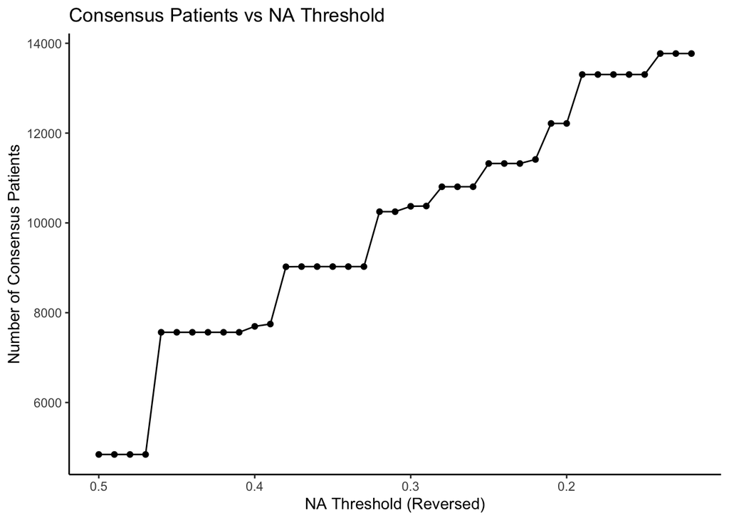

```r
names(consensus_patient_n) <- seq(0.01, 0.5, by = 0.01)
names(filtered_var_n) <- seq(0.01, 0.5, by = 0.01)

# aggregate results in dataframe for plotting
results_df <- data.frame(
  Threshold = seq(0.01, 0.5, by = 0.01),
  Consensus_Patients = consensus_patient_n,
  Filtered_Variables = filtered_var_n
)%>%filter(Filtered_Variables > 0)


# the lower the threshold the more patients
ggplot(results_df, aes(x = Threshold, y = Consensus_Patients)) +
  geom_line() +
  geom_point() +
  scale_x_reverse() +
  labs(
    title = "Consensus Patients vs NA Threshold",
    x = "NA Threshold (Reversed)",
    y = "Number of Consensus Patients"
  ) +
  theme_classic()
```

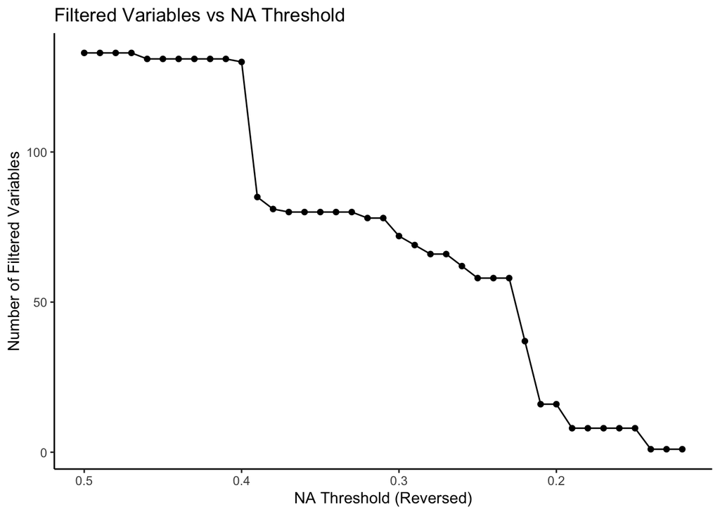

```r
# the lower the threshold the less variables
ggplot(results_df, aes(x = Threshold, y = Filtered_Variables)) +
  geom_line() +
  geom_point() +
  scale_x_reverse() +
  labs(
    title = "Filtered Variables vs NA Threshold",
    x = "NA Threshold (Reversed)",
    y = "Number of Filtered Variables"
  ) +
  theme_classic()
```

```r
# post hoc
label_point <- results_df[results_df$Threshold == 0.31, ]

min(results_df$Filtered_Variables)
```

```
## [1] 1
```

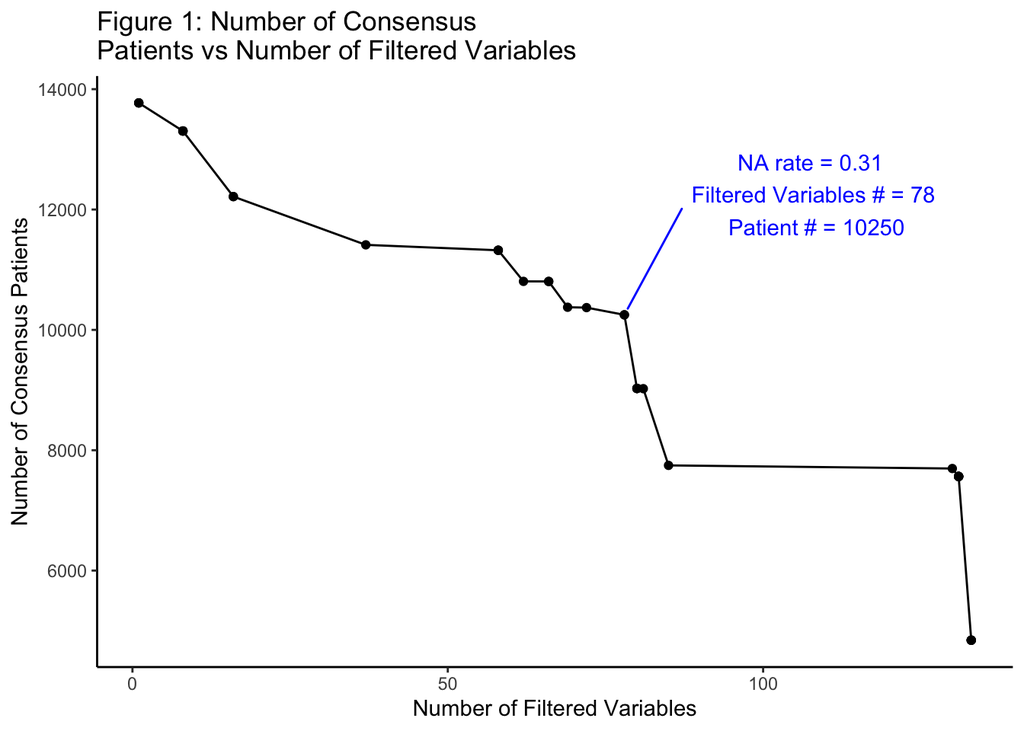

```r
# the more variable the less consensus patients
# pdf(paste0(plot.out.dir, "/na_handling.pdf"), width = 5, height = 4)
ggplot(results_df, aes(x = Filtered_Variables, y = Consensus_Patients)) +
  geom_line() +
  geom_point() +
  geom_text_repel(
    data = label_point,
    aes(label = paste("NA rate =", Threshold, "\n Filtered Variables # =", Filtered_Variables, "\n Patient # =", Consensus_Patients)),
    nudge_x = 30,  # Nudges the label to the right
    nudge_y = 2000, # Nudges the label upwards
    segment.color = "blue", # Line color
    segment.size = 0.5,     # Line thickness
    color = "blue",         # Label text color
    box.padding = 0.5,      # Space around the text
    point.padding = 0.5     # Space around the point
  ) +
  labs(
    title = "Figure 1: Number of Consensus \nPatients vs Number of Filtered Variables",
    x = "Number of Filtered Variables",
    y = "Number of Consensus Patients"
  ) +
  theme_classic()
```

```r
# dev.off()
```

By elbow rule, we pick NA rate to be 0.31, and continue with the leftover data subset.

### How do the selected lab variables correlate with one another?

We want to see what variables seem to group together, but also look at whether or not we see at least some correlation between our hypothesis group of variables (PBCD) and other groups of variables.

```r
selected_vars <- names(na_prop_list[na_prop_list<0.31])
nhane_sub <- nhanes_lab%>%select(selected_vars)%>%drop_na()
```

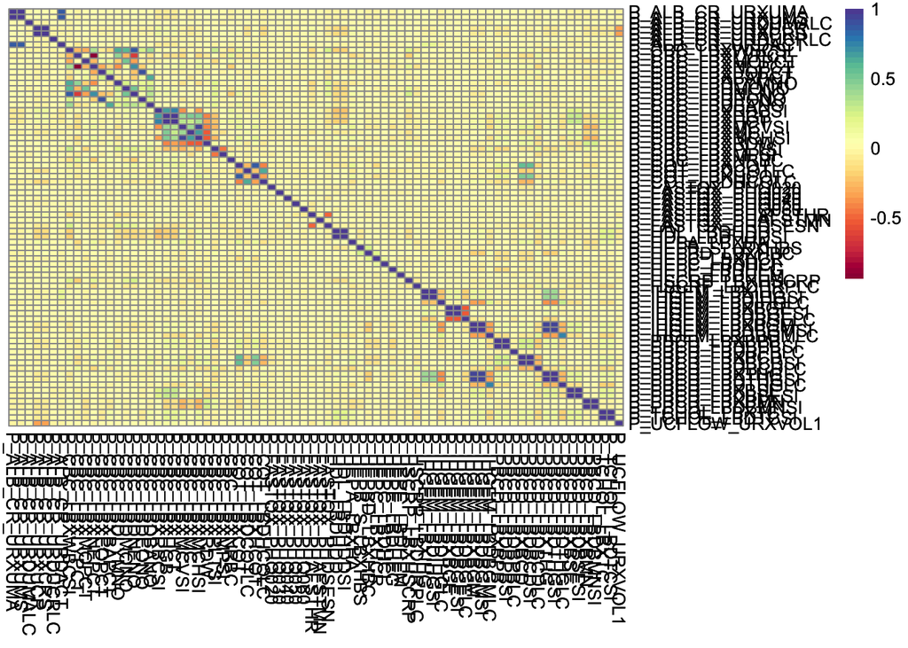

```r
# summary(nhane_sub)

# what are these lab values actually corresponding to?
# table(var_lib%>%filter(BMI_714_Variable_Name %in% colnames(nhane_sub))%>%pull(Data_File_Description))

# large scale correlation check by heatmap
## but first drop two columns that have 0 standard deviation -- the values were probably all 0 anyways
# pdf(paste0(plot.out.dir, "/correlation_subsetted_labvar.pdf"), width = 25, height = 25)
nhane_sub <- nhane_sub[, apply(nhane_sub, 2, sd) != 0]
cor_matrix <- cor(nhane_sub, use = "complete.obs", method = "pearson")
sub_anno <- var_lib%>%
  filter(BMI_714_Variable_Name %in% colnames(nhane_sub))%>%
  select(BMI_714_Variable_Name, Data_File_Description)
cor_matrix_ordered <- cor_matrix[,sub_anno$BMI_714_Variable_Name]
p <- pheatmap(cor_matrix_ordered,
         color = colorRampPalette(brewer.pal(n = 11, name = "Spectral"))(50),
         display_numbers = F, cluster_rows = F, cluster_cols = F)
p
```

```r
# dev.off()
```

Seems like variables within “Complete Blood Count with 5-Part Differential in Whole Blood” and “Cotinine and Hydroxycotinine - Serum” have some strong covariance within the group. Across groups, we see 1) some correlation between some CBC tests and PBCD tests, 2) slight correlation between some PBCD items and HEPB, HEPC, HEPE measurements, 3) notable correlation between blood mercury (P_PBCD_LBXTHG, P_PBCD_LBDTHGSI, P_PBCD_LBDTHGLC) and mercury level in the IHGEM tests…(yeah no sh*t), 4) slight correlation between blood selenium, blood manganese levels and hemoglobin/red cell/platlet measurements

With that, we focus on observation 2), and aim to construct a regression model that can best predict Hepatitis B core antibody (P_HEPBD_LBXHBC) from “Lead, Cadmium, Total Mercury, Selenium, & Manganese - Blood (PBCD)” family of tests. Upon further inspection, we see that there is actually redundancy within the PBCD tests. For example, the three variables P_PBCD_LBXTHG, P_PBCD_LBDTHGSI, and P_PBCD_LBDTHGLC all measure blood mercury, the first in ug/L, second in nmol/L, and the third a code that defines whether or not the level is above some threshold level. We decide to keep only the variables that uses nmol/L for the 5 heavy metal tests because it’s the conventional unit used in research papers. To increase the scope of the variables arrive at 8 variables, we additionally include hematocrit (P_CBC_LBXHCT), mean cell volume (P_CBC_LBXMCVSI), and hemoglobin (P_CBC_LBXHGB).

```r
# creating the dataset with the selected variables
# hep_vars <- intersect(var_lib$BMI_714_Variable_Name[grep("P_HEP", var_lib$Data_File_Name)], colnames(nhane_sub))
hep_vars <- "P_HEPBD_LBXHBC"
analysis_ind_var_vec <- c("P_PBCD_LBDBPBSI", "P_PBCD_LBDBCDSI", "P_PBCD_LBDTHGSI", "P_PBCD_LBDBSESI", "P_PBCD_LBDBMNSI", "P_CBC_LBXHCT", "P_CBC_LBXMCVSI", "P_CBC_LBXHGB")
analysis_var_ref <- var_lib%>%filter(BMI_714_Variable_Name %in% c(hep_vars, analysis_ind_var_vec))
# subset the data to only include the variables of interest
nhane_selected <- nhane_sub%>%
  select(all_of(c(hep_vars, analysis_ind_var_vec)))

nhane_selected$P_HEPBD_LBXHBC <- as.factor(ifelse(nhane_selected$P_HEPBD_LBXHBC == 1, 0, 1))

head(nhane_selected)
```

```
##   P_HEPBD_LBXHBC P_PBCD_LBDBPBSI P_PBCD_LBDBCDSI P_PBCD_LBDTHGSI
## 1              1           0.082           1.984            1.80
## 2              1           0.058           1.254            1.00
## 3              1           0.072          20.552            2.10
## 4              1           0.033           7.473            2.54
## 5              1           0.019           0.632            1.00
## 6              1           0.037           0.979            1.00
##   P_PBCD_LBDBSESI P_PBCD_LBDBMNSI P_CBC_LBXHCT P_CBC_LBXMCVSI P_CBC_LBXHGB
## 1            2.13          161.09         36.5           83.7         12.3
## 2            1.82          161.27         36.9           64.0         12.0
## 3            2.50          126.50         44.3           97.6         15.3
## 4            2.50          104.66         45.5           88.3         15.9
## 5            2.31           68.99         41.3           92.3         13.9
## 6            2.62          158.18         40.4           83.1         13.8
```

```r
cor(nhane_selected[, -1])
```

```
##                 P_PBCD_LBDBPBSI P_PBCD_LBDBCDSI P_PBCD_LBDTHGSI P_PBCD_LBDBSESI
## P_PBCD_LBDBPBSI      1.00000000     0.237559212      0.11580078     0.018287130
## P_PBCD_LBDBCDSI      0.23755921     1.000000000      0.06857577     0.018205506
## P_PBCD_LBDTHGSI      0.11580078     0.068575773      1.00000000     0.172129649
## P_PBCD_LBDBSESI      0.01828713     0.018205506      0.17212965     1.000000000
## P_PBCD_LBDBMNSI     -0.04279195     0.007061727      0.04396184    -0.009452369
## P_CBC_LBXHCT         0.12624294     0.099892137      0.07446464     0.270200836
## P_CBC_LBXMCVSI       0.13485484     0.171938284      0.06779697     0.105518529
## P_CBC_LBXHGB         0.11182160     0.078927683      0.07098962     0.281552557
##                 P_PBCD_LBDBMNSI P_CBC_LBXHCT P_CBC_LBXMCVSI P_CBC_LBXHGB
## P_PBCD_LBDBPBSI    -0.042791953   0.12624294     0.13485484   0.11182160
## P_PBCD_LBDBCDSI     0.007061727   0.09989214     0.17193828   0.07892768
## P_PBCD_LBDTHGSI     0.043961844   0.07446464     0.06779697   0.07098962
## P_PBCD_LBDBSESI    -0.009452369   0.27020084     0.10551853   0.28155256
## P_PBCD_LBDBMNSI     1.000000000  -0.11743614    -0.26440256  -0.13665332
## P_CBC_LBXHCT       -0.117436140   1.00000000     0.33396940   0.97103813
## P_CBC_LBXMCVSI     -0.264402562   0.33396940     1.00000000   0.39666801
## P_CBC_LBXHGB       -0.136653318   0.97103813     0.39666801   1.00000000
```

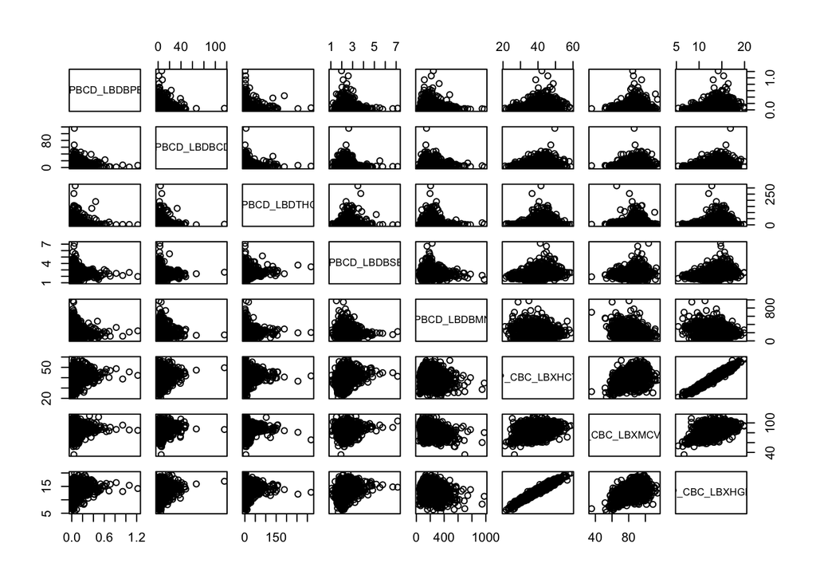

```r
plot(nhane_selected[, -1])
```

```r
# table(nhane_selected$P_HEPBD_LBXHBC)
```

### Scaling

```r
nhane_selected <- nhane_selected %>%
  mutate(across(!matches("P_HEPBD_LBXHBC"), ~ (. - mean(.)) / sd(.)))
```

### Test-train split

```r
set.seed(714)
# since we have so many observations we can do 0.7 train prop (i'm so happy)
train_prop <- 0.7

n <- nrow(nhane_selected)

# train_indices <- sample(1:n, size = floor(train_prop * n))
# using this protocol to ensure equal ratio of case/control in train/test
train_indices <- createDataPartition(nhane_selected$P_HEPBD_LBXHBC, p = 0.7, list = FALSE)

nhane_train <- nhane_selected[train_indices, ]   # Training set
nhane_test <- nhane_selected[-train_indices, ]  # Test set

# Check the sizes
cat("Training set size:", nrow(nhane_train), "\n")
```

```
## Training set size: 7176
```

```r
cat("Test set size:", nrow(nhane_test), "\n")
```

```
## Test set size: 3074
```

```r
cat("Class proportions in training set:\n")
```

```
## Class proportions in training set:
```

```r
print(prop.table(table(nhane_train$P_HEPBD_LBXHBC)))
```

```
##
##          0          1
## 0.05755295 0.94244705
```

```r
cat("Class proportions in test set:\n")
```

```
## Class proportions in test set:
```

```r
print(prop.table(table(nhane_test$P_HEPBD_LBXHBC)))
```

```
##
##          0          1
## 0.05725439 0.94274561
```

## Model Building

### Logistic Regression

We have 8 continuous independent variables and 1 binary dependent variable. We will use logistic regression to predict the probability of having Hepatitis B core antibody based on the 8 blood test results. I am interested in investigating the performance and analyzing different approaches to feature selection.

#### Approach 1: Backward Elimination with $\\beta_1$ significance level of 0.05

```r
# fit a full model
fit_full <- glm(P_HEPBD_LBXHBC ~ ., data = nhane_train, family = binomial)
# summary(fit_full)   #P_PBCD_LBDBMNSI is not significant

fit1_1 <- update(fit_full, . ~ . - P_PBCD_LBDBMNSI)
# summary(fit1_1) #P_PBCD_LBDBSESI is not significant

fit1 <- update(fit1_1, . ~ . - P_PBCD_LBDBSESI)
summary(fit1)
```

```
##
## Call:
## glm(formula = P_HEPBD_LBXHBC ~ P_PBCD_LBDBPBSI + P_PBCD_LBDBCDSI +
##     P_PBCD_LBDTHGSI + P_CBC_LBXHCT + P_CBC_LBXMCVSI + P_CBC_LBXHGB,
##     family = binomial, data = nhane_train)
##
## Coefficients:
##                 Estimate Std. Error z value Pr(>|z|)
## (Intercept)      2.99820    0.05842  51.319  < 2e-16 ***
## P_PBCD_LBDBPBSI -0.19531    0.03367  -5.800 6.63e-09 ***
## P_PBCD_LBDBCDSI -0.18163    0.03582  -5.070 3.97e-07 ***
## P_PBCD_LBDTHGSI -0.36717    0.03657 -10.041  < 2e-16 ***
## P_CBC_LBXHCT    -1.23465    0.23281  -5.303 1.14e-07 ***
## P_CBC_LBXMCVSI  -0.27795    0.05882  -4.726 2.29e-06 ***
## P_CBC_LBXHGB     1.31313    0.24148   5.438 5.39e-08 ***
## ---
## Signif. codes:  0 '***' 0.001 '**' 0.01 '*' 0.05 '.' 0.1 ' ' 1
##
## (Dispersion parameter for binomial family taken to be 1)
##
##     Null deviance: 3160.0  on 7175  degrees of freedom
## Residual deviance: 2904.1  on 7169  degrees of freedom
## AIC: 2918.1
##
## Number of Fisher Scoring iterations: 6
```

```r
# all variables are p<0.05, we are done now
```

#### Approach 2: Backward Elimination with AIC

```r
fit_null <- glm(P_HEPBD_LBXHBC ~ 1, data = nhane_train, family = binomial)
fit2 <- step(fit_full, scope = list(lower = fit_null, upper = fit_full), data = nhane_train, direction = "backward", trace = F, k = 2)
summary(fit2)
```

```
##
## Call:
## glm(formula = P_HEPBD_LBXHBC ~ P_PBCD_LBDBPBSI + P_PBCD_LBDBCDSI +
##     P_PBCD_LBDTHGSI + P_CBC_LBXHCT + P_CBC_LBXMCVSI + P_CBC_LBXHGB,
##     family = binomial, data = nhane_train)
##
## Coefficients:
##                 Estimate Std. Error z value Pr(>|z|)
## (Intercept)      2.99820    0.05842  51.319  < 2e-16 ***
## P_PBCD_LBDBPBSI -0.19531    0.03367  -5.800 6.63e-09 ***
## P_PBCD_LBDBCDSI -0.18163    0.03582  -5.070 3.97e-07 ***
## P_PBCD_LBDTHGSI -0.36717    0.03657 -10.041  < 2e-16 ***
## P_CBC_LBXHCT    -1.23465    0.23281  -5.303 1.14e-07 ***
## P_CBC_LBXMCVSI  -0.27795    0.05882  -4.726 2.29e-06 ***
## P_CBC_LBXHGB     1.31313    0.24148   5.438 5.39e-08 ***
## ---
## Signif. codes:  0 '***' 0.001 '**' 0.01 '*' 0.05 '.' 0.1 ' ' 1
##
## (Dispersion parameter for binomial family taken to be 1)
##
##     Null deviance: 3160.0  on 7175  degrees of freedom
## Residual deviance: 2904.1  on 7169  degrees of freedom
## AIC: 2918.1
##
## Number of Fisher Scoring iterations: 6
```

#### Approach 3: Iterative Evaluation

Method taken from Aparna, pseudo code below:

Let the set of predictor variables be $V$, Construct a null model $M_0$ Let $M_curr$ be $M_0$ while $V$ is not empty for each $v \in V$ fit a univariate model $M_{v}$ with $v$ run F test to compare $M_{v}$ to $M_{curr}$ record $v$ and the p value of the F test ($p_v$) for $M_v$ in a table

if all $p_v$ > 0.05, stop else identify $v$ with $min(p_v)$ $M_curr$=$M_v$ $V$ = $V$ - $v$

```r
# initialize model and variable set
curr_ind_var_set <- analysis_ind_var_vec
fit_iter <- fit_null
while (length(curr_ind_var_set) > 0) {
  # initiatlize var stat table
  var_sig <- data.frame()
  for (ind_var in curr_ind_var_set) {
    # create a formula with +1 variable
    formula_in <- as.formula(paste(paste(deparse(formula(fit_iter)), collapse = ""), "+", ind_var))

    # fit the model
    fit <- glm(formula_in, data = nhane_train, family = binomial)

    # pulls out p value of this F-test
    curr_p <- anova(fit_iter, fit)[[5]][2]

    # store the variable, p value, and AIC
    var_sig <- rbind(var_sig, data.frame(var = ind_var, p_value = curr_p))
  }

  if (all(var_sig$p_value > 0.05)) {
    # if all p values are > 0.05, stop
    fit3 <- fit_iter
    cat("Finished iterative variable selection, check below for the summary of final model\n")
    break
  }

  # best var by p value
  best_var_p <- var_sig[var_sig$p_value == min(var_sig$p_value),]$var
  fit_iter <- update(fit_iter, as.formula(paste(". ~ . +", best_var_p)))
  curr_ind_var_set <- curr_ind_var_set[curr_ind_var_set != best_var_p]

  cat(paste(best_var_p, "added to the model\n"))
}
```

```
## P_PBCD_LBDTHGSI added to the model
## P_PBCD_LBDBPBSI added to the model
## P_PBCD_LBDBCDSI added to the model
## P_CBC_LBXMCVSI added to the model
## Finished iterative variable selection, check below for the summary of final model
```

```r
summary(fit3)
```

```
##
## Call:
## glm(formula = P_HEPBD_LBXHBC ~ P_PBCD_LBDTHGSI + P_PBCD_LBDBPBSI +
##     P_PBCD_LBDBCDSI + P_CBC_LBXMCVSI, family = binomial, data = nhane_train)
##
## Coefficients:
##                 Estimate Std. Error z value Pr(>|z|)
## (Intercept)      2.95460    0.05628  52.499  < 2e-16 ***
## P_PBCD_LBDTHGSI -0.36250    0.03644  -9.949  < 2e-16 ***
## P_PBCD_LBDBPBSI -0.20215    0.03379  -5.982 2.21e-09 ***
## P_PBCD_LBDBCDSI -0.20027    0.03631  -5.516 3.46e-08 ***
## P_CBC_LBXMCVSI  -0.17012    0.05554  -3.063  0.00219 **
## ---
## Signif. codes:  0 '***' 0.001 '**' 0.01 '*' 0.05 '.' 0.1 ' ' 1
##
## (Dispersion parameter for binomial family taken to be 1)
##
##     Null deviance: 3160.0  on 7175  degrees of freedom
## Residual deviance: 2934.1  on 7171  degrees of freedom
## AIC: 2944.1
##
## Number of Fisher Scoring iterations: 6
```

#### Quick comparison before moving forward

Now that we have the three models, let’s compare

```r
#Backward Elimination with $\\beta_1$ significance level of 0.05
summary(fit1)
```

```
##
## Call:
## glm(formula = P_HEPBD_LBXHBC ~ P_PBCD_LBDBPBSI + P_PBCD_LBDBCDSI +
##     P_PBCD_LBDTHGSI + P_CBC_LBXHCT + P_CBC_LBXMCVSI + P_CBC_LBXHGB,
##     family = binomial, data = nhane_train)
##
## Coefficients:
##                 Estimate Std. Error z value Pr(>|z|)
## (Intercept)      2.99820    0.05842  51.319  < 2e-16 ***
## P_PBCD_LBDBPBSI -0.19531    0.03367  -5.800 6.63e-09 ***
## P_PBCD_LBDBCDSI -0.18163    0.03582  -5.070 3.97e-07 ***
## P_PBCD_LBDTHGSI -0.36717    0.03657 -10.041  < 2e-16 ***
## P_CBC_LBXHCT    -1.23465    0.23281  -5.303 1.14e-07 ***
## P_CBC_LBXMCVSI  -0.27795    0.05882  -4.726 2.29e-06 ***
## P_CBC_LBXHGB     1.31313    0.24148   5.438 5.39e-08 ***
## ---
## Signif. codes:  0 '***' 0.001 '**' 0.01 '*' 0.05 '.' 0.1 ' ' 1
##
## (Dispersion parameter for binomial family taken to be 1)
##
##     Null deviance: 3160.0  on 7175  degrees of freedom
## Residual deviance: 2904.1  on 7169  degrees of freedom
## AIC: 2918.1
##
## Number of Fisher Scoring iterations: 6
```

```r
#Backward elimination with AIC
summary(fit2)
```

```
##
## Call:
## glm(formula = P_HEPBD_LBXHBC ~ P_PBCD_LBDBPBSI + P_PBCD_LBDBCDSI +
##     P_PBCD_LBDTHGSI + P_CBC_LBXHCT + P_CBC_LBXMCVSI + P_CBC_LBXHGB,
##     family = binomial, data = nhane_train)
##
## Coefficients:
##                 Estimate Std. Error z value Pr(>|z|)
## (Intercept)      2.99820    0.05842  51.319  < 2e-16 ***
## P_PBCD_LBDBPBSI -0.19531    0.03367  -5.800 6.63e-09 ***
## P_PBCD_LBDBCDSI -0.18163    0.03582  -5.070 3.97e-07 ***
## P_PBCD_LBDTHGSI -0.36717    0.03657 -10.041  < 2e-16 ***
## P_CBC_LBXHCT    -1.23465    0.23281  -5.303 1.14e-07 ***
## P_CBC_LBXMCVSI  -0.27795    0.05882  -4.726 2.29e-06 ***
## P_CBC_LBXHGB     1.31313    0.24148   5.438 5.39e-08 ***
## ---
## Signif. codes:  0 '***' 0.001 '**' 0.01 '*' 0.05 '.' 0.1 ' ' 1
##
## (Dispersion parameter for binomial family taken to be 1)
##
##     Null deviance: 3160.0  on 7175  degrees of freedom
## Residual deviance: 2904.1  on 7169  degrees of freedom
## AIC: 2918.1
##
## Number of Fisher Scoring iterations: 6
```

```r
#Iterative evaluation
summary(fit3)
```

```
##
## Call:
## glm(formula = P_HEPBD_LBXHBC ~ P_PBCD_LBDTHGSI + P_PBCD_LBDBPBSI +
##     P_PBCD_LBDBCDSI + P_CBC_LBXMCVSI, family = binomial, data = nhane_train)
##
## Coefficients:
##                 Estimate Std. Error z value Pr(>|z|)
## (Intercept)      2.95460    0.05628  52.499  < 2e-16 ***
## P_PBCD_LBDTHGSI -0.36250    0.03644  -9.949  < 2e-16 ***
## P_PBCD_LBDBPBSI -0.20215    0.03379  -5.982 2.21e-09 ***
## P_PBCD_LBDBCDSI -0.20027    0.03631  -5.516 3.46e-08 ***
## P_CBC_LBXMCVSI  -0.17012    0.05554  -3.063  0.00219 **
## ---
## Signif. codes:  0 '***' 0.001 '**' 0.01 '*' 0.05 '.' 0.1 ' ' 1
##
## (Dispersion parameter for binomial family taken to be 1)
##
##     Null deviance: 3160.0  on 7175  degrees of freedom
## Residual deviance: 2934.1  on 7171  degrees of freedom
## AIC: 2944.1
##
## Number of Fisher Scoring iterations: 6
```

We note fit3 is strictly nested within fit1(=fit2). We will do an F test on the two models, and compare AIC scores.

```r
# fit3 has fewest variables, let's see if adding the dropped variable improves the model
anova(fit3, fit1)
```

```
## Analysis of Deviance Table
##
## Model 1: P_HEPBD_LBXHBC ~ P_PBCD_LBDTHGSI + P_PBCD_LBDBPBSI + P_PBCD_LBDBCDSI +
##     P_CBC_LBXMCVSI
## Model 2: P_HEPBD_LBXHBC ~ P_PBCD_LBDBPBSI + P_PBCD_LBDBCDSI + P_PBCD_LBDTHGSI +
##     P_CBC_LBXHCT + P_CBC_LBXMCVSI + P_CBC_LBXHGB
##   Resid. Df Resid. Dev Df Deviance  Pr(>Chi)
## 1      7171     2934.1
## 2      7169     2904.1  2   30.018 3.031e-07 ***
## ---
## Signif. codes:  0 '***' 0.001 '**' 0.01 '*' 0.05 '.' 0.1 ' ' 1
```

```r
AIC(fit3, fit1)
```

```
##      df      AIC
## fit3  5 2944.076
## fit1  7 2918.057
```

```r
# rational var naming
fit_logi <- fit1# fit1 is the best model
```

#### Ridge Regression

We will now perform ridge regression on the selected variables to see if we can improve the model and prevent overfitting. We will examine whether or not ridge indeed lives up to its promise. We will use cross-validation to find the best lambda value.

```r
# Ridge regularization because want to retain all covariates
# remove the variables that were dropped during variable selection
nhane_train_ridge <- nhane_train%>%
  select(-c(P_PBCD_LBDBSESI, P_PBCD_LBDBMNSI))
nhane_test_ridge <- nhane_test%>%
  select(-c(P_PBCD_LBDBSESI, P_PBCD_LBDBMNSI))

nhanes_matrix <- apply(nhane_train_ridge, 2, as.numeric)

#set alpha to 0 for ridge
set.seed(714)
nhanes_model_ridge <- cv.glmnet(nhanes_matrix[,!colnames(nhanes_matrix) %in% "P_HEPBD_LBXHBC"], nhanes_matrix[,"P_HEPBD_LBXHBC"], nfolds = 10, alpha = 0)
best_lambda <- nhanes_model_ridge$lambda.min
fit_ridge <- glmnet(nhanes_matrix[,!colnames(nhanes_matrix) %in% "P_HEPBD_LBXHBC"], nhanes_matrix[,"P_HEPBD_LBXHBC"], alpha = 0, lambda=best_lambda)
ridge_coefficients<- coef(fit_ridge)
ridge_coefficients_vector <- as.vector(ridge_coefficients)
names(ridge_coefficients_vector) <- rownames(ridge_coefficients)
```

We now compare the coefficients from the ridge regularization to the coefficients of fit_out.

```r
comparison_df <- data.frame(
  Ridge = ridge_coefficients_vector,
  Standard = fit_logi$coefficients[names(ridge_coefficients_vector)]
)
comparison_df
```

```
##                        Ridge   Standard
## (Intercept)      0.942439536  2.9982044
## P_PBCD_LBDBPBSI -0.018627326 -0.1953109
## P_PBCD_LBDBCDSI -0.015882659 -0.1816324
## P_PBCD_LBDTHGSI -0.041417644 -0.3671726
## P_CBC_LBXHCT    -0.029174523 -1.2346476
## P_CBC_LBXMCVSI  -0.009065754 -0.2779509
## P_CBC_LBXHGB     0.032880467  1.3131336
```

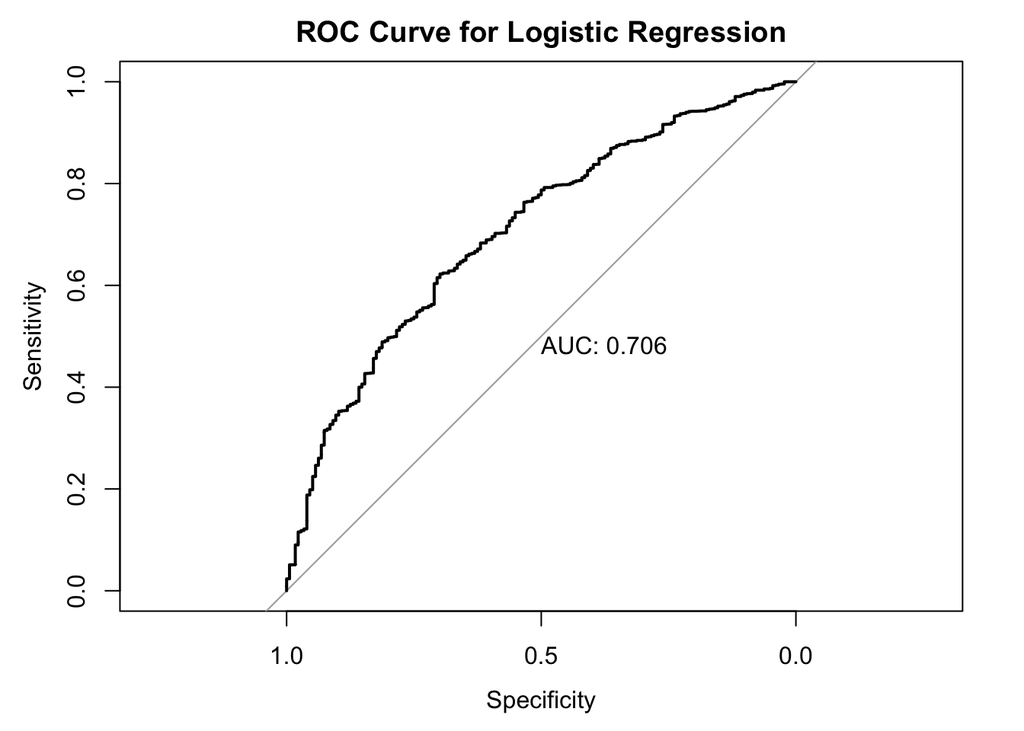

```r
# model eval with regular logistic regression
predicted_probs <- predict(fit_logi, newdata = nhane_test, type = "response")
predicted_classes <- ifelse(predicted_probs > 0.5, 1, 0)
# table(predicted_classes)
actual_classes <- nhane_test[, "P_HEPBD_LBXHBC"]
# table(actual_classes)
confusion_matrix_logi <- table(Predicted = predicted_classes, Actual = actual_classes)
roc_logi <- roc(actual_classes, predicted_probs, plot = T, print.auc = T, main = "ROC Curve for Logistic Regression")
```

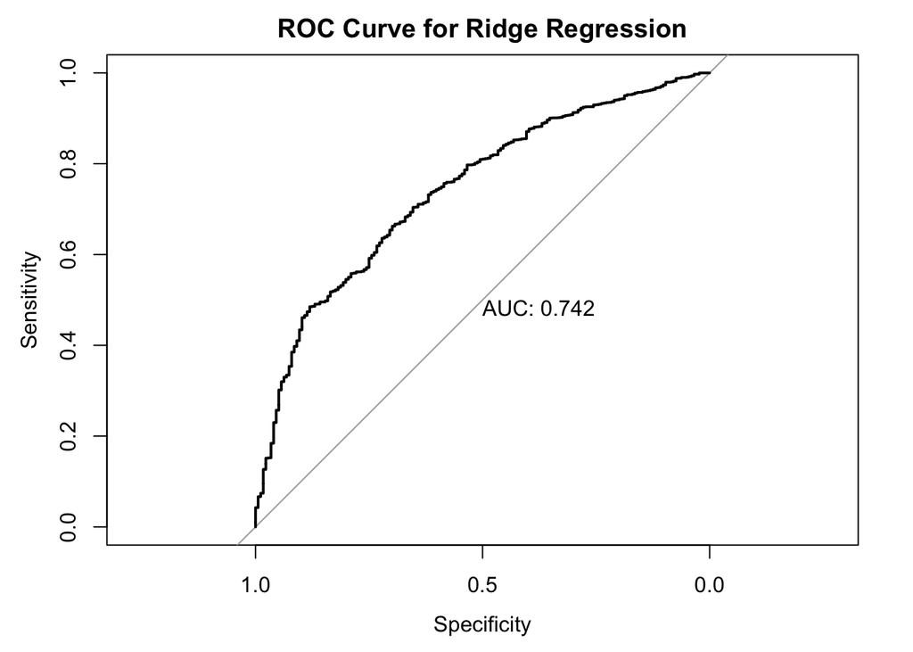

```r
# model eval with ridge
predicted_probs <- predict(fit_ridge, newx = as.matrix(nhane_test_ridge[, !colnames(nhane_test_ridge) %in% "P_HEPBD_LBXHBC"]), s = "lambda.min", type = "response")
predicted_classes <- ifelse(predicted_probs > 0.5, 1, 0)
# table(predicted_classes)
actual_classes <- nhane_test_ridge[, "P_HEPBD_LBXHBC"]
# table(actual_classes)
confusion_matrix_ridge <- table(Predicted = predicted_classes, Actual = actual_classes)
roc_logi_ridge <- roc(actual_classes, predicted_probs, plot = T, print.auc = T, main = "ROC Curve for Ridge Regression")
```

We now obtain the overview of metrics for the two models.

```r
# define a function to get metrics from confusion matrix
calculate_metrics <- function(confusion_matrix) {
  TN <- confusion_matrix[1, 1]
  FP <- confusion_matrix[1, 2]
  FN <- confusion_matrix[2, 1]
  TP <- confusion_matrix[2, 2]
  sensitivity <- TP / (TP + FN)
  specificity <- TN / (TN + FP)

  # return a quick list of metrics
  return(list(
    Sensitivity = sensitivity,
    Specificity = specificity,
    False_Negatives = FN,
    False_Positives = FP
  ))
}
```

```r
# perform the functinos on the confusion matrix
metrics_logistic <- calculate_metrics(confusion_matrix_logi)
metrics_ridge <- calculate_metrics(confusion_matrix_ridge)

# make a df
evaluation_df <- data.frame(
  Model = c("Logistic Regression", "Ridge Regression"),
  Sensitivity = c(metrics_logistic$Sensitivity, metrics_ridge$Sensitivity),
  Specificity = c(metrics_logistic$Specificity, metrics_ridge$Specificity),
  False_Negatives = c(metrics_logistic$False_Negatives, metrics_ridge$False_Negatives),
  False_Positives = c(metrics_logistic$False_Positives, metrics_ridge$False_Positives)
)

evaluation_df
```

```
##                 Model Sensitivity Specificity False_Negatives False_Positives
## 1 Logistic Regression   0.9438459   0.3636364             172               7
## 2    Ridge Regression   0.9439374   0.6666667             172               2
```

## Model Diagnostics

### Bootstrapping for CI

First define a function that takes in a model and outputs coefficients as required by boot. This performs 1000 bootstrapping to generate a distribution (and therefore 95 CI) for each coefficient. We use the training set instead of the whole dataset because the model that we want to diagnose is built on training data so bootstrapping using it mirrors this process and helps validate its stability.

```r
# create the data pool for bootstrapping
bs_dat <- nhane_train%>%
  select(-c(P_PBCD_LBDBSESI, P_PBCD_LBDBMNSI))

x <- model.matrix(P_HEPBD_LBXHBC ~ ., data = bs_dat)[, -1]
y <- as.numeric(bs_dat$P_HEPBD_LBXHBC) - 1

pb <- progress_bar$new(total = 1001)
# ridge regression bootstrapping function
ridge_boot_fn <- function(in_dat, idx) {
  pb$tick()
  # get the bootstrap sample
  x_boot <- in_dat[idx, 2:7]
  y_boot <- in_dat[idx, 1]

  # edge case where y is all the same
  if (length(unique(y_boot)) == 1) {
    cat("all y are same level")
    return(rep(NA, ncol(x_boot) + 1))  # Return NA coefficients for this sample
  }

  # fit ridge, I know finding best lambda for each boot is time consuming
  # it's not too bad (~1 min) so we'll go for that accuracy
  pre_cv <- cv.glmnet(x_boot, y_boot, nfolds = 10, alpha = 0)
  best_lambda <- pre_cv$lambda.min
  fit_ridge <- glmnet(x_boot, y_boot, alpha = 0, lambda=best_lambda)

  # get coefficients
  return(as.numeric(coef(fit_ridge)))
}

# perform boot
data_list <- list(x = x, y = y)
set.seed(714)
ridge_boot_results <- boot(
  data = cbind(y,x),
  statistic = ridge_boot_fn,
  R = 1000
)

ridge_boot_results
```

```
##
## ORDINARY NONPARAMETRIC BOOTSTRAP
##
##
## Call:
## boot(data = cbind(y, x), statistic = ridge_boot_fn, R = 1000)
##
##
## Bootstrap Statistics :
##         original        bias    std. error
## t1*  0.942439536 -6.874493e-06 0.002714481
## t2* -0.018627326 -2.145398e-04 0.004051000
## t3* -0.015882659 -4.144808e-05 0.003497166
## t4* -0.041417644  2.334645e-04 0.004760878
## t5* -0.029174523 -1.746847e-04 0.007506580
## t6* -0.009065754 -9.893262e-05 0.003127756
## t7*  0.032880467  5.708727e-06 0.007616568
```

### Permutation to Check Calibration

Now let’s do 1000 permutation and look at the null distribution of the coefficients and the distribution p values. Again, we use training set as the base to ensure consistency.

```r
x <- nhanes_matrix[,!colnames(nhanes_matrix) %in% "P_HEPBD_LBXHBC"]
y <- nhanes_matrix[,"P_HEPBD_LBXHBC"]

set.seed(714)
# first calculate original model performance, note this is not on test set
original_model <- cv.glmnet(x, y, alpha = 0, nfolds = 10)
original_lambda <- original_model$lambda.min
original_fit <- glmnet(x, y, alpha = 0, lambda = original_lambda)
coef(fit_ridge)
```

```
## 7 x 1 sparse Matrix of class "dgCMatrix"
##                           s0
## (Intercept)      0.942439536
## P_PBCD_LBDBPBSI -0.018627326
## P_PBCD_LBDBCDSI -0.015882659
## P_PBCD_LBDTHGSI -0.041417644
## P_CBC_LBXHCT    -0.029174523
## P_CBC_LBXMCVSI  -0.009065754
## P_CBC_LBXHGB     0.032880467
```

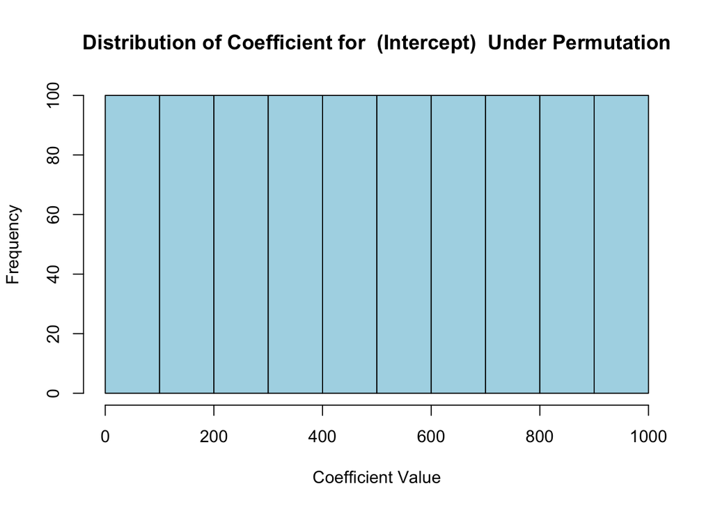

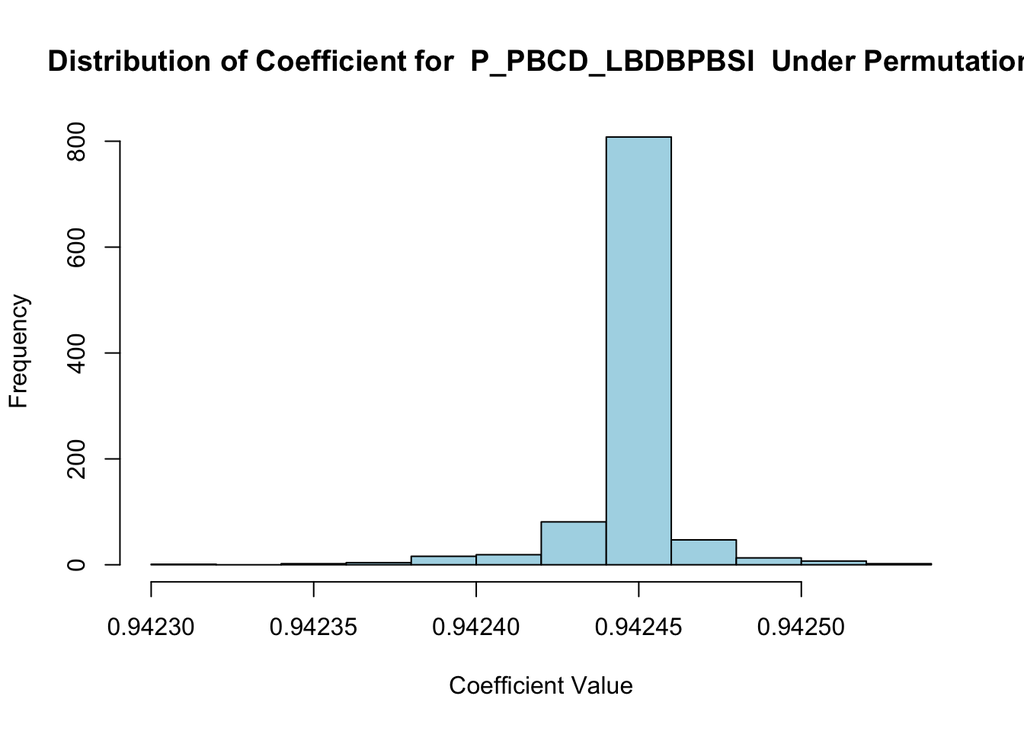

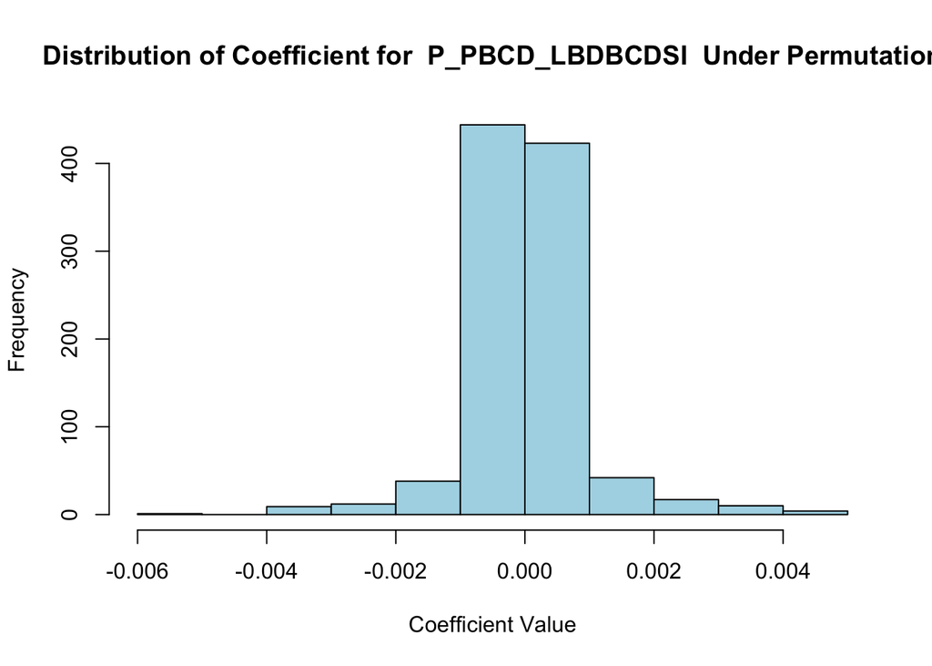

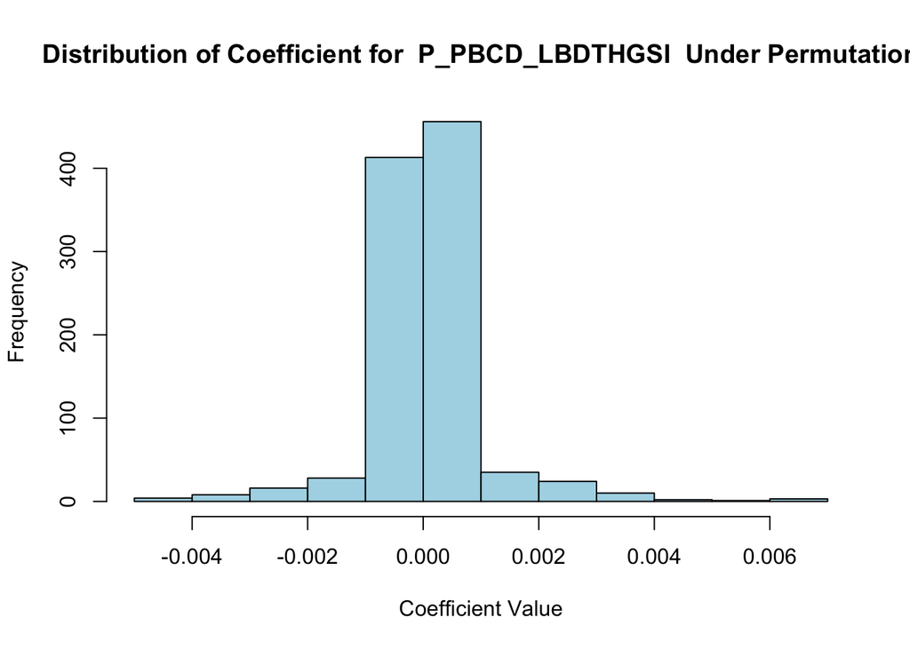

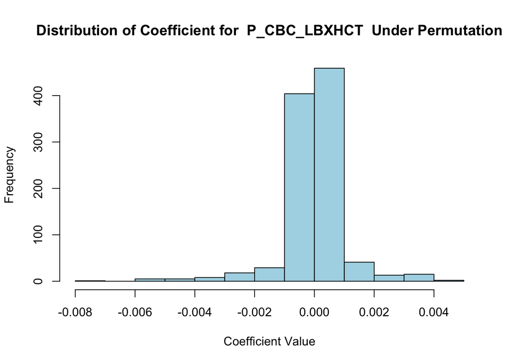

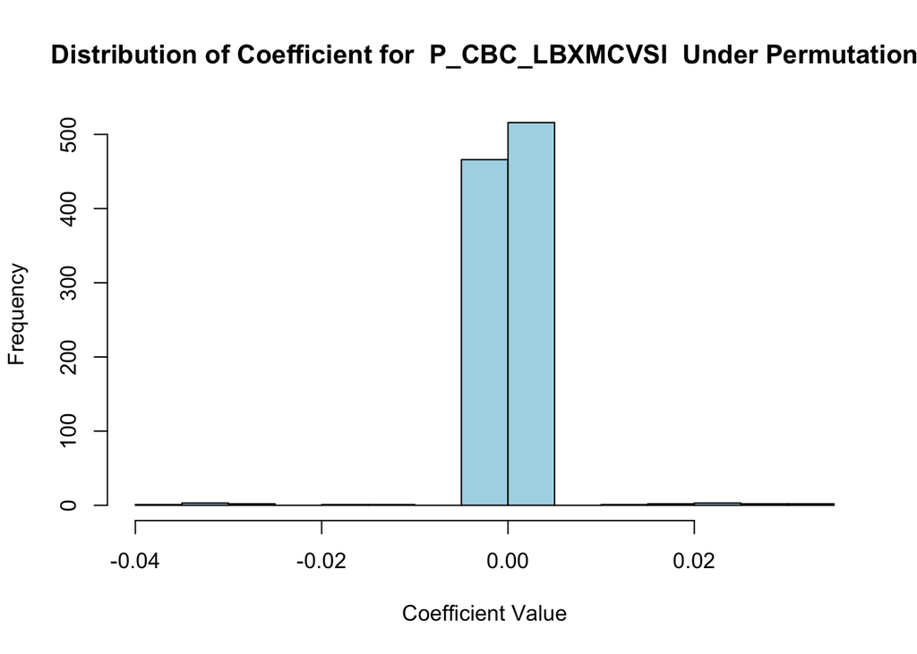

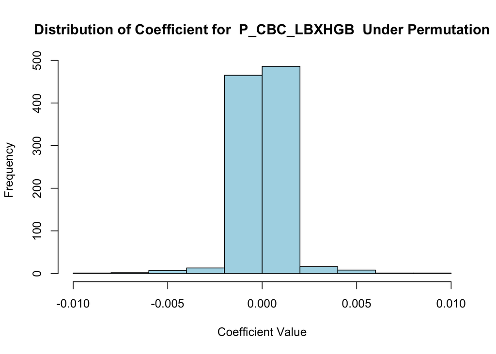

```r
original_coefs <- as.numeric(coef(original_fit))  # Include intercept
coef_names <- rownames(coef(original_fit))

# we now calculate performance for each permutation
set.seed(714)
n_perm <- 1000
perm_coefs <- matrix(NA, nrow = n_perm, ncol = length(original_coefs))
perm_p_val <- matrix(NA, nrow = n_perm, ncol = length(original_coefs))

pb <- progress_bar$new(total = 1001)
for (i in 1:n_perm) {
  pb$tick()
  # Permute y
  y_permuted <- sample(y)

  # ridge for coefficient
  permuted_model <- cv.glmnet(x, y_permuted, alpha = 0, nfolds = 10)
  permuted_lambda <- permuted_model$lambda.min
  permuted_fit <- glmnet(x, y_permuted, alpha = 0, lambda = permuted_lambda)
  perm_coefs[i, ] <- as.numeric(coef(permuted_fit))

  # regular glm for p value
  glm_fit <- glm(y_permuted ~ x, family = "binomial")

  glm_summary <- summary(glm_fit)
  perm_p_val[i, ] <- as.numeric(glm_summary$coefficients[, 4])
}
coef_names <- c("(Intercept)", colnames(x))

# coefficient tbl and histogram
coef_value_tbl <- data.frame(Permutation = 1:n_perm, perm_coefs)
colnames(coef_value_tbl) <- c("Permutation", coef_names)
for (i in 1:length(coef_names)) {
  hist(
    coef_value_tbl[, i],
    main = paste("Distribution of Coefficient for ", coef_names[i], " Under Permutation"),
    xlab = "Coefficient Value",
    col = "lightblue"
  )
}
```

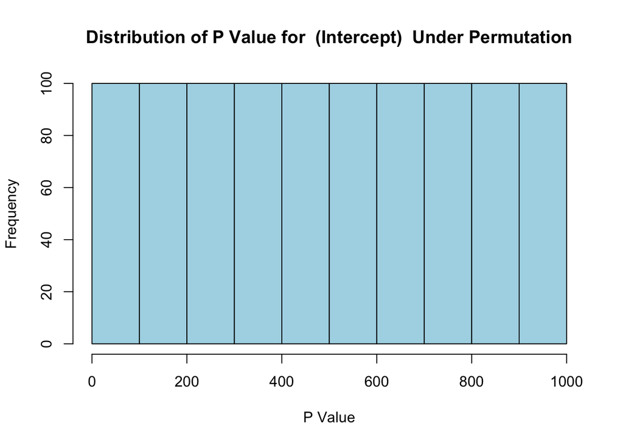

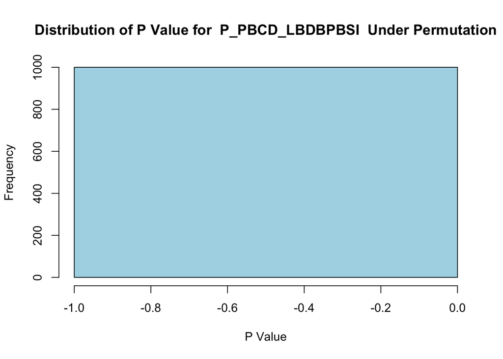

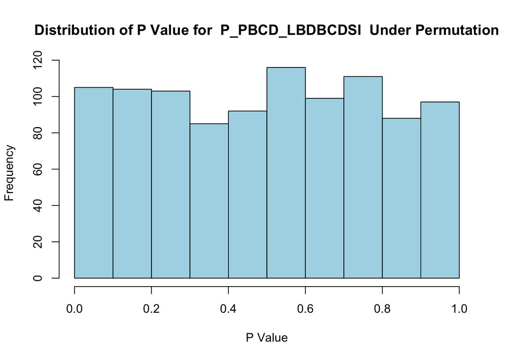

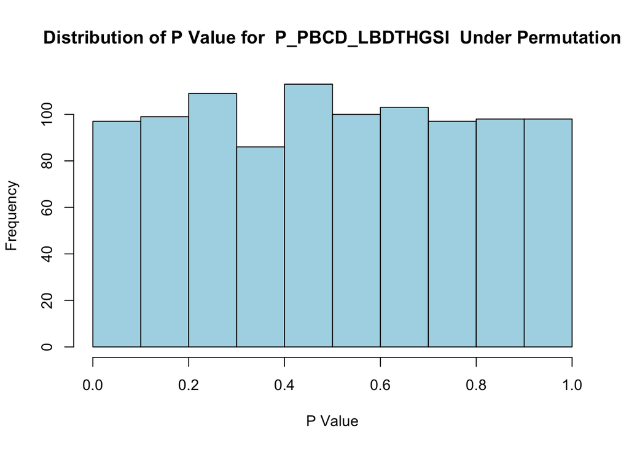

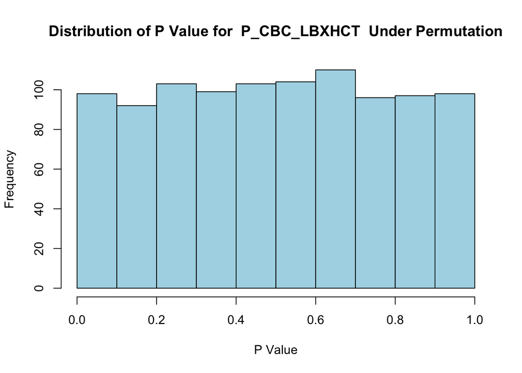

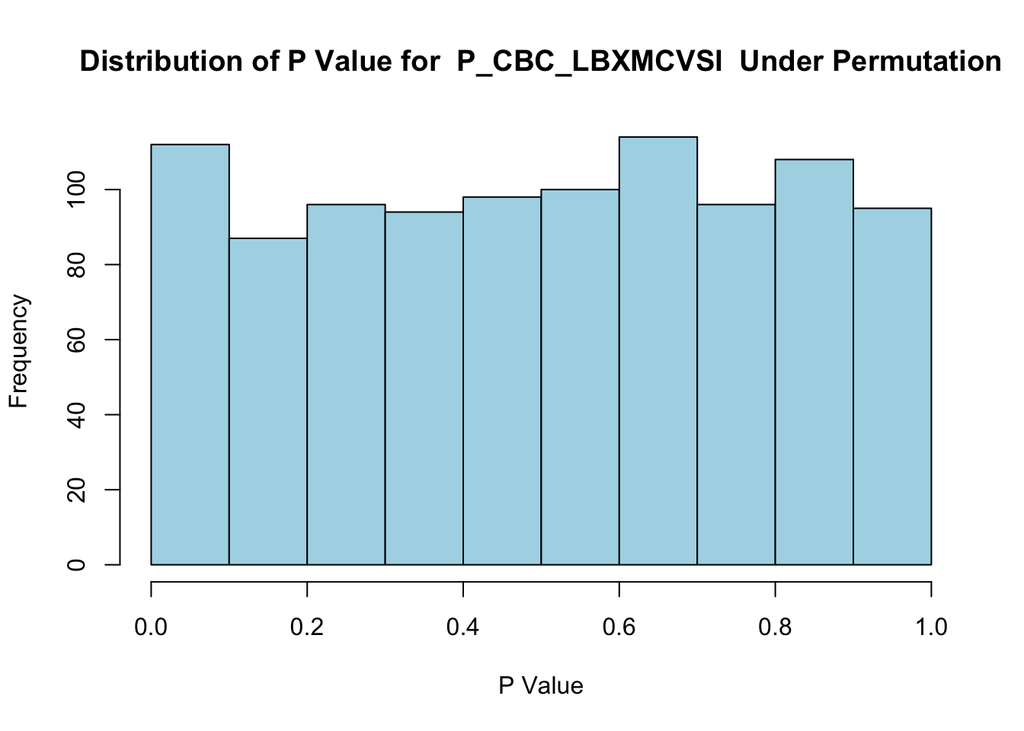

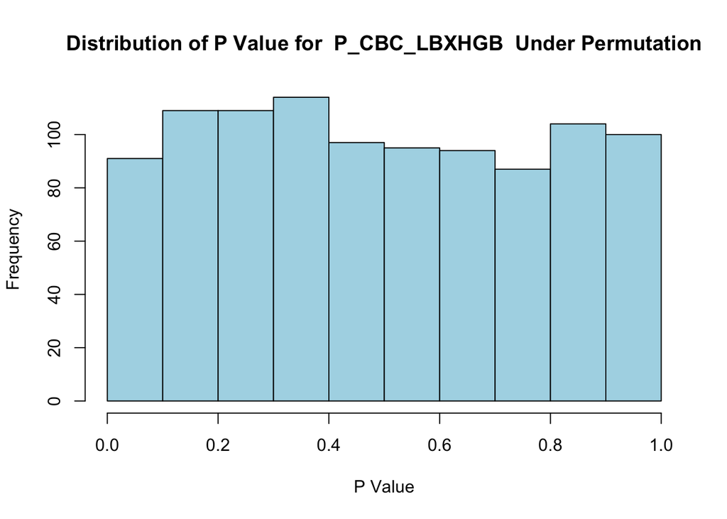

```r
# p value tbl and histogram
p_value_tbl <- data.frame(Permutation = 1:n_perm, perm_p_val)
colnames(p_value_tbl) <- c("Permutation", coef_names)
for (i in 1:length(coef_names)) {
  hist(
    p_value_tbl[, i],
    main = paste("Distribution of P Value for ", coef_names[i], " Under Permutation"),
    xlab = "P Value",
    col = "lightblue"
  )
}
```